# CellTagging: a combinatorial indexing method for lineage tracing

Single-cell technologies are offering unprecedented insight into complex biology, revealing the behavior of rare cell populations that are typically masked in bulk population analyses. The application of these methodologies to cell fate reprogramming holds particular promise as the manipulation of cell identity is typically inefficient, generating heterogeneous cell populations. One current limitation of single-cell approaches is that lineage relationships are lost as a result of cell processing, restricting interpretations of the data collected. Here, we present a single-cell resolution clonal tracking approach, based on combinatorial cell indexing, permitting the parallel capture of lineage information and cell identity. “CellTagging” integrates with high-throughput single-cell RNA-sequencing, where iterative rounds of cell labeling enable the construction of multi-level lineage trees. We apply this technology to reveal the transcriptional dynamics of direct reprogramming from fibroblasts to induced endoderm progenitors. CellTagging and tracking of clones over a four-week reprogramming timecourse consisting of over 100,000 profiled cells reveals two distinct trajectories: one culminating in successfully reprogrammed cells, and one leading to a ‘dead-end’ state, resulting in re-expression of genes associated with the starting cell type. Although these trajectories are established early, there appears to be considerable heterogeneity during fate conversion. We find that expression of the putative methyltransferase, Mettl7a1 is associated with the successful reprogramming trajectory, where its addition to the reprogramming cocktail increases the yield of iEPs. Together, these results demonstrate the utility of our clonal tracking approach to quantify stochastic and deterministic phases of lineage reprogramming, and will be of broad utility in many cell biological applications.

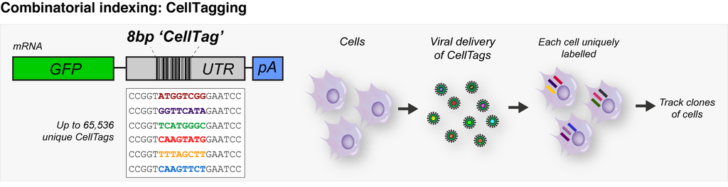

[CellTag bioRxiv Preprint](https://www.biorxiv.org/content/early/2017/04/28/127860)  
[Morris Lab Website](http://morrislab.wustl.edu/)  
[Inspired by DropViz](http://dropviz.org)